# STAT 240

Week 2: More R Background

Owen G. Ward

## This week

- Some more details on the hot hand (a simple data science example)
- More R review
  - Reading data/files into R
  - Some plotting
  - Relaxed pace, please ask questions if you have them!
- This course does not assume you know R, so there is time built in for any/all questions!

## Labs

- Lab this week just set up, making sure you can submit the required pdf
- Next week first problem set posted, attendance taken
- Questions about logistics?

## Office Hours

- My office hours will be in K10561
- Wednesday 2.30-3.15pm (Straight after class)
- Thursday 3.00-3.45pm
- Common for 240/260, let me know if you can’t make either time

## Returning to the hot hand

- Last time, we examined the “hot hand” hypothesis, and did one revolution around the wheel of science:

```r
data <- read.csv("shot_logs.csv")

data <- data[order(
  data$player_name, data$GAME_ID,
  data$PERIOD, data$SHOT_NUMBER
), ]

W <- 0
X <- 0
Y <- 0
Z <- 0
...
```

```
Scoring percent after making a shot: 44.8%
```

```
Scoring percent after missing a shot: 45.5%
```

## Hot hand, part 2

- We found the scoring percent after making a shot was in fact smaller than the scoring percent after missing a shot. There are several problems with our analysis, and more questions that emerge.
- This is common when you do data science!
  - Discuss your initial findings with experts, revise and iterate
- The most immediate is that the organization of our `for` loop is incorrect

[figure not shown]

—“Vince Carter (blue) tries to make a layup shot, while Pau Gasol (yellow) defends the basket”

## Hot hand, part 2

- Suppose the sorted shot log looks like this:

| PLAYER | GAME.ID | SHOT.NUMBER | SHOT.RESULT |
| --- | --- | --- | --- |
| james harden | 1 | 1 | MADE |
| stephen curry | 2 | 1 | MADE |
| stephen curry | 2 | 2 | MISSED |

- For this shot log and our *week01* code `hothand.r`, the first shot made by Stephen Curry in the second game is incorrectly counted as a successful shot by the player for which their immediately previously shot was successful, yielding this incorrect table: (**Discussion**: What is the correct table?)

|  | MADE | MISSED |
| --- | --- | --- |
| HOT | 1 | 1 |
| NOT | 0 | 0 |

## Hot hand, part 2

- We need to do the tabulation one player at a time, one game at a time. This is done in `hothand2.r` by adding additional logic, cleaning up the mistake:

```r
...
W = 0; X = 0; Y = 0; Z = 0
for (i in 2:dim(data)[1]) {
  if (data$GAME_ID[i - 1] == data$GAME_ID[i] &&
    data$player_name[i - 1] == data$player_name[i]) {
    if (data$SHOT_RESULT[i - 1] == "made") { # HOT
      ...
```

```
Scoring percent after making a shot: 44.8%
Scoring percent after missing a shot: 45.9%
```

- The result is essentially unchanged, which was expected as only a small fraction of shots are affected by the mistake

## To think about

- Suppose you were asked how many shots were affected. How could you compute this?
- Type of thing a manager could ask, handy to have the number ready (or know how to get it!)

## Hot hand, part ?

- **Discussion**: Now that our code is correct, is this evidence of a “cold” hand (45.9% > 44.8%, is the difference of 1.1% *significant*)? If we were to do another revolution around the wheel of science, how could we improve this analysis?
- Only the 2014-2015 season is examined, and all players are examined. Maybe the hot hand is season specific? Maybe it is player specific?
- We’ve defined a hot hand as an improved chance of “making” the next shot, after each “made” shot.
- The hot hand as a concept does not have a precise definition (leading us to start by making a candidate definition).
- Maybe the hot hand would emerge after a less conservative definition (for example, we might examine if “making” 3 or more out of the 5 previous shots improves the percent chance of “making” the next shot)
- Any mistakes in the assumptions, or the code?

## Hot hand, significance

- Just because two percentages differ doesn’t mean there’s evidence that the underlying processes differ
- Consider this example: I flip coin $A$ 7 times and it comes up heads 5 times (~71% of the time). I flip coin $B$ 10 times and it comes up heads 3 times (30% of the time). **Discussion**: Is this evidence that coin $A$ will come up heads more often (in future flips)?

|  | HEADS | TAILS |
| --- | --- | --- |
| Coin $A$ | 5 | 2 |
| Coin $B$ | 3 | 7 |

## Hot hand, significance

- We can figure out if data are evidence for something by using $p$-values and null hypotheses.
- For the coins, the null hypothesis we will use is that coin $A$ and coin $B$ come up heads the same percentage of the time.
- With this null hypothesis, we can use the *Fisher exact test* to find a $p$-value:

```r
example <- data.frame(HEADS = c(5, 3), TAILS = c(2, 7))
rownames(example) <- c("A", "B")
fisher.test(example)$p.value
```

```
[1] 0.1534348
```

```r
example <- data.frame(HEADS = c(5, 3), TAILS = c(2, 7))
rownames(example) <- c("A", "B")
fisher.test(example)$p.value
```

```
[1] 0.1534348
```

- The $p$-value is 0.15. This means that if the null hypothesis were true (if coin $A$ and coin $B$ truly come up heads the same percentage of the time), then 15% of the time, the data would look “as or more extreme” than what was observed

## Fisher’s Exact Test

- One of the oldest and simplest hypothesis tests
- First developed by Ronald Fisher, an extremely influential but controversial figure
- Credited with founding much of modern statistics

## The exact test

- Can actually get the distribution of the counts in the table here, conditional on the marginals (the row sums)
  - How many times you flip each coin
- Means we can compute the probability of the table observed, under the null hypothesis
  - Similar to a calculation you may have seen in Stat 270
- Along with any table that is as or more extreme!
- Any test you have seen before, such as a t-test, is an approximation using the central limit theorem
- This test is exact, doesn’t need a large sample to give a valid result

## A/B Testing

- While this test might seem simple, it’s extremely useful in Data Science!
- Commonly seen in industry (tech, advertising, etc) as an A/B test

## A/B Testing

- Suppose you want to see if adding a photo to your promo email leads to more people clicking on the link
- Send different (random) people the same email, some have the photo, some don’t (no other difference)
- Compute the proportion who click the link in each setting (**click through rate**)
- Then can use this test to see if the photo leads to more clicks, with statistical guarantees

## A/B Testing and Causal Inference

- This might seem like a very simple setting, but it is in fact the simplest form of **Causal Inference**
- This is the holy grail of scientific understanding. Does A cause B? In this example, does an image in an email cause more people to go to a website?

## Causal Inference

- We are interested in knowing a **potential outcome**.
- Would someone be more likely to click on the link, if they had seen the image?
- We never observe this
- Causal inference allows us to reason about questions like this carefully
- A key requirement is that the email (treatment) received is random for each person, which is only possible in idealized problems

## Hot hand, significance

- If the $p$-value were really small (generally, significance starts at $p<0.05$), it would mean that if the null hypothesis were true, the chance of seeing the sort of data that was seen is really small:
- That’s evidence *against* the null hypothesis. For coins $A$ and $B$ in this example, there’s no statistical evidence that the percentage of heads differ
- Let’s look at a $p$-value for our hot hand experiment:

```r
result <- data.frame(MADE = c(W, Y), MISSED = c(X, Z))
fisher.test(result)$p.value
```

```
[1] 0.0004026706
```

- Interesting: This is in fact statistical evidence for a “cold” hand
- What is our null hypothesis here? Other potential issues with our analysis can impact this also

## Hot hand, player specific

- Taking a step back, let’s consider the other discussion point and examine hot hand in a single player, Steph Curry
- Do we expect to see the same result when we look at a subset of our data instead?
- We subset to shots for this player:

```r
...
# Examines hot hand for Stephen Curry.
data <- read.csv("shot_logs.csv")
data <- data[data$player_name == "stephen curry", ]
data <- data[order(
  data$GAME_ID, data$PERIOD,
  data$SHOT_NUMBER
), ]

W <- 0
X <- 0
Y <- 0
Z <- 0
for (i in 2:dim(data)[1]) {
  if (data$GAME_ID[i - 1] == data$GAME_ID[i]) {
    ...
cat(sprintf("p-value: %.2e\n", fisher.test(result)$p.value))
```

```r
...
# Examines hot hand for Stephen Curry.
data <- read.csv("shot_logs.csv")
data <- data[data$player_name == "stephen curry", ]
data <- data[order(
  data$GAME_ID, data$PERIOD,
  data$SHOT_NUMBER
), ]

W <- 0
X <- 0
Y <- 0
Z <- 0
for (i in 2:dim(data)[1]) {
  if (data$GAME_ID[i - 1] == data$GAME_ID[i]) {
    ...
cat(sprintf("p-value: %.2e\n", fisher.test(result)$p.value))
```

```
Scoring percent after making a shot: 44.5%
Scoring percent after missing a shot: 52.2%
p-value: 2.03e-02
```

## Hot hand, player specific

```r
...
data <- data[data$player_name == "stephen curry", ]
...
```

- This line of code subsets the rows of `data` using *logical indexing*
- Here `data$player_name == "stephen curry"` is a vector of `TRUE` or `FALSE` values with length given by the number of rows in `data`
- Rows are in the subset if their corresponding value in the vector is `TRUE`

## Logical indexing

```r
a <- c(6, 24, 96, 384, 1536)
b <- c(TRUE, TRUE, FALSE, TRUE, FALSE)
print(a[b])
```

```
[1]   6  24 384
```

- Logical indexing works for vectors as well as data frames

```r
a <- c(6, 24, 96, 384, 1536)
print(a > 25)
```

```
[1] FALSE FALSE  TRUE  TRUE  TRUE
```

```r
print(a[a > 25])
```

```
[1]   96  384 1536
```

## Logical indexing

Again, here is what it looks like for the example shot log from the first slides:

```r
example <- data.frame(PLAYER = c("james harden", "stephen curry", "stephen curry"),
                      GAME.ID = c("1", "2", "2"),
                      SHOT.NUMBER = c("1", "1", "2"),
                      SHOT.RESULT = c("MADE", "MADE", "MISSED"))
print(example$PLAYER == "stephen curry")
```

```
[1] FALSE  TRUE  TRUE
```

```r
example <- example[example$PLAYER == "stephen curry", ]
```

|  | PLAYER | GAME.ID | SHOT.NUMBER | SHOT.RESULT |
| --- | --- | --- | --- | --- |
| 2 | stephen curry | 2 | 1 | MADE |
| 3 | stephen curry | 2 | 2 | MISSED |

## Displaying this table

- R has some functions for displaying data in a nicer format
- Here we are using the `kable` function from the `knitr` package

```r
kable(example)
```

|  | PLAYER | GAME.ID | SHOT.NUMBER | SHOT.RESULT |
| --- | --- | --- | --- | --- |
| 2 | stephen curry | 2 | 1 | MADE |
| 3 | stephen curry | 2 | 2 | MISSED |

## R packages

- We can install these packages locally using `install.package("package_name")`
- Then these packages need to be loaded when used using `library(package_name)`
- Note the use/absence of “” here
  - Need “” when installing packages
  - Don’t need it when loading packages

# Reading Files

## Reading flat files

- Moving on: The first step of `hothand.r` and our extensions is reading in a file. What does this mean, and how do we do it?

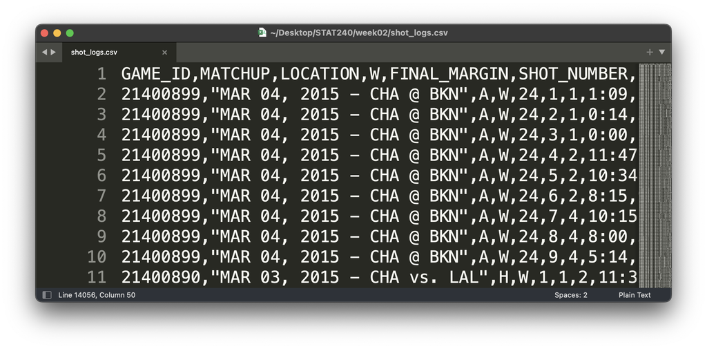

- Here we have the shot log *comma separated variable* file. We read it with:

```r
data <- read.csv("shot_logs.csv")
```

## Reading flat files

- A file is a sequence of bytes
- Bytes are 8-bit values (they take the range 0 - 255)
- According to the “ASCII” table (American Standard Code for Information Interchange), the range of values 32 - 126 contains the Latin alphabet without accents and punctuation (the range 128 - 165 contains accented Latin letters)
- Some Greek letters appear in the range 224 - 235
- [Unicode](https://home.unicode.org) can be used to specify characters in a long list of scripts (Cyrillic, Arabic, Ethiopic, … [“Unicode covers all the characters for all the writing systems of the world, modern and ancient.”](https://www.unicode.org/standard/supported.html))
- A unicode character is a short sequence of bytes known as a code point

## Reading flat files

- Some files (`.png` for images, `.xlsx` for spreadsheets, `.pdf` for documents) use their own format for the meaning and layout of the byte values in the file
- A file is called a flat file if it uses the ASCII or Unicode encoding (we can read the file if we open it in a “text editor”—A program such as *notepad* that displays the ASCII or Unicode characters on the screen)

## Filesystems

- Every file resides in a directory. When we do `read.csv("shot_logs.csv")`, R Studio will look in its current working directory for a file named `shot_logs.csv` and give an error if that file doesn’t exist
- You can change R Studio’s working directory using the function `setwd` or using the file browser in the *Files* tab in the lower right pane of R Studio

## Files and folders

- Understanding filesystems and folders are an important (but boring) skill for any data scientist
- For large datasets, might not be able to open the file directly (what if there are millions/billions of observation)
- Might not even have the data on your own machine
  - Stored on company server which you can read, but only from the command line
  - This will be a Unix system

## The R working directory

- The **working directory** is where the analysis in a script/markdown document takes place
- By default, this is where R will look for data files and save output
- This will depend on where the script is itself saved and some other settings
- Can see this on the console or using `getwd()`

## Filepaths

- If you want to access something outside of your working directory you need to tell R where it is
- For example, if I wanted to access `shot_logs.csv` from anywhere on my computer I would need the **absolute path** to it

```r
data <- read.csv("/Users/owen/Documents/Github/stat_240/shot_logs.csv")
```

```r
data <- read.csv("/Users/owen/Documents/Github/stat_240/shot_logs.csv")
```

- Can use `/` for both Windows and Mac in R
- Note if anyone else ran this code it wouldn’t work, unique to my machine
- This is a problem when you want to share code
- Thankfully there are better ways of doing this!

## R Studio Projects

- RStudio provides what are known as Projects
- You should set one up for this course, and place all of your code, files inside of it!
- When you open an RStudio Project the working directory for all scripts in that project is where the project is saved
- Only need to worry about relative paths inside the project

## Relative Paths

- I have `shot_logs.csv` inside a folder in my project
- I only need to tell R the path inside the project to open it

```r
data <- read.csv("slides/week_02/shot_logs.csv")
```

- If you had a copy of this project (set up correctly) this code would run on your computer too!

## Reading files in a markdown document

- When you run code inside a qmd file (even inside a project) the working directory is where that file is saved!
- So to correctly load in the data in this file

```r
## as this file in slides/week_02/ already
data <- read.csv("shot_logs.csv")
```

## Reading flat files

- Flat files come in many formats (the only defining characteristic is they can be read by eye in a text editor). Here’s a *tab separated variable file* containing historical stock prices for 27 NASDAQ stocks on November 17th, 2015 (this file `AS-N100.tsv` is provided in the folder for this lecture):

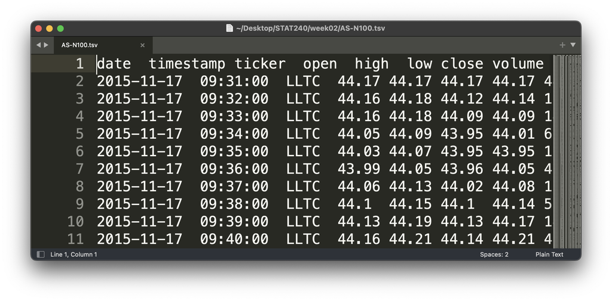